# Human Activity Recognition: Barbell Lifts

author: Iga Korneta

date: Saturday, August 16, 2014

**Synopsis:** The following writeup was created for the Coursera Practical Machine Learning course, edition Aug. 4, 2014. It describes a machine learning model purporting to predict the type of human activity (either correct or one of four possible types of incorrect barbell lifting) from recorded Human Activity Recognition (HAR) data.

**Raw data:** I downloaded the training/validation and testing data from the course website: [training/validation](https://d396qusza40orc.cloudfront.net/predmachlearn/pml-training.csv); [testing](https://d396qusza40orc.cloudfront.net/predmachlearn/pml-testing.csv). Data reference: [Velloso et al., Qualitative Activity Recognition of Weight Lifting Exercises](http://groupware.les.inf.puc-rio.br/har#weight_lifting_exercises) (full reference in link).

```r
# code has eval=FALSE
download.file('https://d396qusza40orc.cloudfront.net/predmachlearn/pml-training.csv', 'pml-training.csv')
download.file('https://d396qusza40orc.cloudfront.net/predmachlearn/pml-testing.csv', 'pml-training.csv')
```

**Exploratory data analysis:** The training/validation data file contained 19622 observations of 160 variables. However, many of the variables contained in fact mostly (>70%) NAs or blank strings (treated as NAs). Some variables described sample-identifying information such as timestamps, which would also be useless for modelling. After removing these variables, I ended up with 52 numeric variables as input for modelling + the target variable “classe” as the output.

```r
# for the curious, I follow a data-preparation template outlined here: http://onepager.togaware.com/
# code has results='hide'
library (caret)
library (ggplot2)
library (gridExtra)

pml.training <- read.csv('./pml-training.csv', na.strings=c("NA", ""))
pml.testing <- read.csv('./pml-testing.csv', na.strings=c("NA", ""))

names(pml.training)
str(pml.training)
summary(pml.training)

vars <- names(pml.training)
#these are 'identifying variables'
id <- c("X", "user_name", "raw_timestamp_part_1", "raw_timestamp_part_2", "cvtd_timestamp", "new_window", "num_window")
ignore <- id

#these are variables with  >70% obs missing
mvc <- sapply(pml.training[vars], function(x) sum(is.na(x)))
mvn <- names(which(mvc >= 0.7*nrow(pml.training)))
ignore <- union(ignore, mvn)

vars <- setdiff(vars, ignore)
```

**Model building, part 1:** I split the training/validation set into training and validation. I also standardised the variables while at that.

Note: it’s not an typo that I split the training/validation set into 30% **training** and 70% **validation**, even though it should be the other way round. My laptop is incredibly slow, so the other way round, I could really only do a single tree model (accuracy: 37% :-/).

Anyway - I gambled that 30% of the set was still 5889 observations and would be enough to get decent results. As it so happens, the gamble paid off (see below).

```r
set.seed(4444)
in.train <- createDataPartition(pml.training$classe, p=0.3, list=FALSE)
train.set  <- pml.training[in.train, vars]
val.set <- pml.training[-in.train, vars]

train.preproc.cent.scale <- preProcess(train.set[,-53], method=c("center", "scale"))
train.set <- cbind(predict(train.preproc.cent.scale, train.set[,-53]), classe=train.set[,53])
val.set <- cbind(predict(train.preproc.cent.scale, val.set[,-53]), classe=val.set[,53])
```

**Model building, part 2:** I did a PCA on the training set to find out how the variance was split, and also to facilitate model building.

```r
train.preproc.pca <- preProcess(train.set[,-53], method="pca", thresh=0.8)
train.set.pca <- cbind(predict(train.preproc.pca, train.set[,-53]), classe=train.set[,53])
val.set.pca <- cbind(predict(train.preproc.pca, val.set[,-53]), classe=val.set[,53])
```

I set the threshold to 80% of total variance because, according to the output, PCA needed 13 components to capture 80% of the variance, but as many as 26 components to capture 95%. Again, doing it with 26 components took forever.

This is the plot of the first two components, coloured by the outcome:

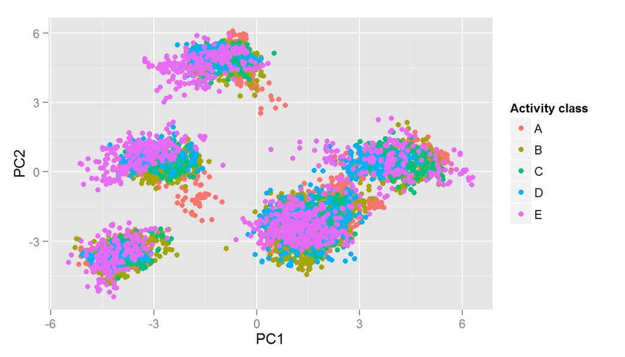

**Model building, part 3:** Now came the time for me to choose the type of method to predict with. Initially, I planned to try out all the available methods, but it quickly turned out that the physical limitations of my laptop meant that calculations took forever. In the end, I tried only the following:

- single tree (“rpart”)

```r
set.seed(1112)
modfit.rpart.pca <- train(classe~., method="rpart", data=train.set.pca)
predict.rpart.pca <- predict(modfit.rpart.pca, newdata=val.set.pca)
confusion.matrix.rpart.pca <- confusionMatrix(val.set$classe, predict.rpart.pca)
confusion.matrix.rpart.pca
```

[output not shown]

- random forest (“rf”)

I tried to build this predictor, but didn’t manage to get a result. I lost my patience after 10 minutes of my laptop trying to churn through the calculations.

```r
set.seed(1112)
modfit.rf.pca <- train(classe~., method="rf", data=train.set.pca, prox=TRUE)
predict.rf.pca <- predict(modfit.rf.pca, newdata=val.set.pca)
confusion.matrix.rf.pca <- confusionMatrix(val.set$classe, predict.rf.pca)
confusion.matrix.rf.pca
```

- boosted trees (“gbm”)

I trained this predictor on the 80%-variance PCA threshold (13 components) and on a 30%-of-total-samples training set (5889 observations). As seen from the output below, the accuracy on the validation set turned out to be 75.1%, i.e. an out-of-sample error of 25%. At that point, since the original publication [showcased accuracy of 74-86% depending on the class](http://groupware.les.inf.puc-rio.br/har#weight_lifting_exercises), I decided that I wasn’t really up for redoing the exercise again, and gave up. :-)

```r
set.seed(1112)
modfit.gbm.pca <- train(classe~., method="gbm", data=train.set.pca)
predict.gbm.pca <- predict(modfit.gbm.pca, newdata=val.set.pca)
confusion.matrix.gbm.pca <- confusionMatrix(val.set$classe, predict.gbm.pca)
res["gbm.pca", "Accuracy"] <- confusion.matrix.gbm.pca$overall["Accuracy"]
confusion.matrix.gbm.pca
```

```
## Confusion Matrix and Statistics
##
##           Reference
## Prediction    A    B    C    D    E
##          A 3264  168  198  216   60
##          B  259 1899  279  103  117
##          C  387  170 1678   81   79
##          D  168  105  249 1642   87
##          E  157  224  172  138 1833
##
## Overall Statistics
##
##                Accuracy : 0.751
##                  95% CI : (0.744, 0.758)
##     No Information Rate : 0.308
##     P-Value [Acc > NIR] : <2e-16
##
##                   Kappa : 0.684
##  Mcnemar's Test P-Value : <2e-16
##
## Statistics by Class:
##
##                      Class: A Class: B Class: C Class: D Class: E
## Sensitivity             0.771    0.740    0.651    0.753    0.842
## Specificity             0.932    0.932    0.936    0.947    0.940
## Pos Pred Value          0.836    0.715    0.701    0.729    0.726
## Neg Pred Value          0.901    0.940    0.921    0.953    0.969
## Prevalence              0.308    0.187    0.188    0.159    0.158
## Detection Rate          0.238    0.138    0.122    0.120    0.133
## Detection Prevalence    0.284    0.193    0.174    0.164    0.184
## Balanced Accuracy       0.852    0.836    0.794    0.850    0.891
```